# Assignment6_MA

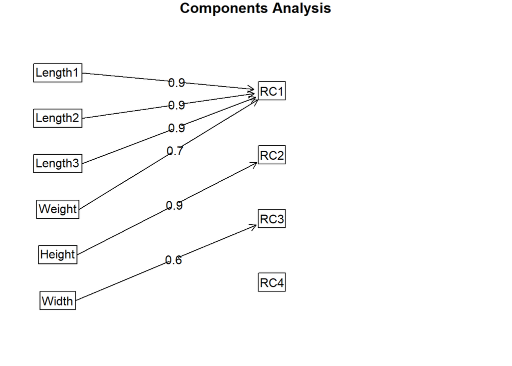

```r
fa.diagram(fit.pc_fish)
```

```r
vss(fish_data[-1])
```

[output not shown]

[output cut: 44 more lines]

[output not shown]

[output not shown]

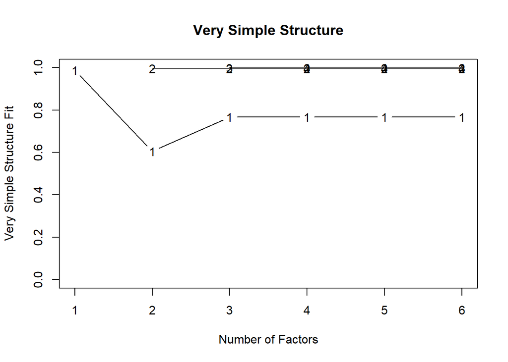

```
##
## Very Simple Structure
## Call: vss(x = fish_data[-1])
## VSS complexity 1 achieves a maximimum of 0.99  with  1  factors
## VSS complexity 2 achieves a maximimum of 1  with  2  factors
##
## The Velicer MAP achieves a minimum of 0.39  with  1  factors
## BIC achieves a minimum of  1065.86  with  1  factors
## Sample Size adjusted BIC achieves a minimum of  1094.35  with  1  factors
##
## Statistics by number of factors
##   vss1 vss2  map dof   chisq     prob sqresid  fit  RMSEA     BIC   SABIC
## 1 0.99    0 0.39   9 1.1e+03 1.6e-233   0.335 0.99   0.88 1.1e+03 1.1e+03
## 2 0.61    1 0.51   4 4.8e+08  0.0e+00   0.057 1.00 869.55 4.8e+08 4.8e+08
## 3 0.77    1 0.69   0 1.9e+02       NA   0.023 1.00     NA      NA      NA
## 4 0.77    1 0.74  -3 1.9e+02       NA   0.023 1.00     NA      NA      NA
## 5 0.77    1 1.00  -5 1.8e+02       NA   0.023 1.00     NA      NA      NA
## 6 0.77    1   NA  -6 1.8e+02       NA   0.023 1.00     NA      NA      NA
##   complex  eChisq   SRMR eCRMS eBIC
## 1     1.0 11.1719 0.0485 0.063  -34
## 2     1.6  0.1710 0.0060 0.012  -20
## 3     1.6  0.0055 0.0011    NA   NA
## 4     1.6  0.0055 0.0011    NA   NA
## 5     1.6  0.0055 0.0011    NA   NA
## 6     1.6  0.0055 0.0011    NA   NA
```

```r
# Computing Correlation Matrix
corrm.fish <- cor(fish_data[-1])
corrm.fish
```

```
##            Weight   Length1   Length2   Length3    Height     Width
## Weight  1.0000000 0.9157195 0.9186031 0.9230903 0.7238573 0.8866536
## Length1 0.9157195 1.0000000 0.9995162 0.9920042 0.6244087 0.8666843
## Length2 0.9186031 0.9995162 1.0000000 0.9940830 0.6395032 0.8732011
## Length3 0.9230903 0.9920042 0.9940830 1.0000000 0.7026548 0.8781887
## Height  0.7238573 0.6244087 0.6395032 0.7026548 1.0000000 0.7924005
## Width   0.8866536 0.8666843 0.8732011 0.8781887 0.7924005 1.0000000
```

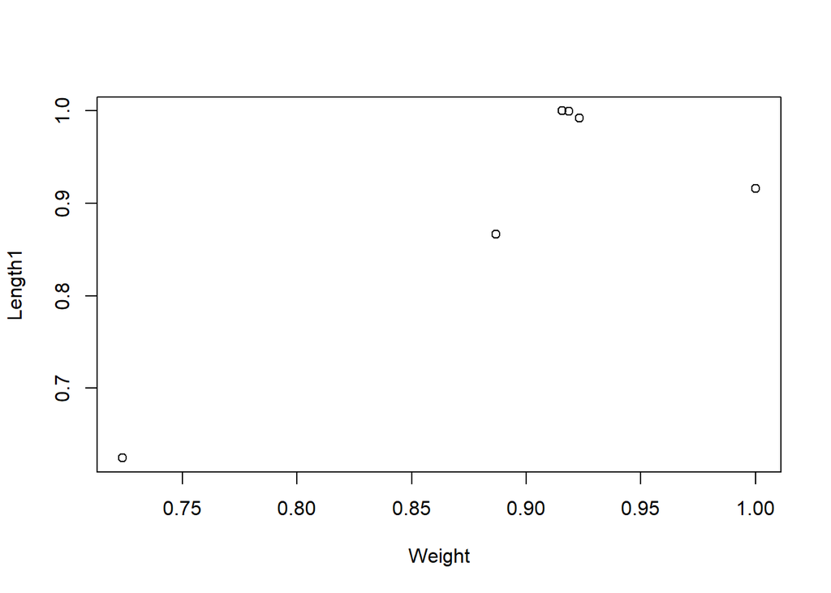

```r
plot(corrm.fish)
```

```r
fish_pca <- prcomp(fish_data[-1], scale=TRUE)
summary(fish_pca)
```

```
## Importance of components:
##                           PC1    PC2     PC3     PC4     PC5     PC6
## Standard deviation     2.2953 0.7154 0.34734 0.31190 0.03974 0.01666
## Proportion of Variance 0.8781 0.0853 0.02011 0.01621 0.00026 0.00005
## Cumulative Proportion  0.8781 0.9634 0.98348 0.99969 0.99995 1.00000
```

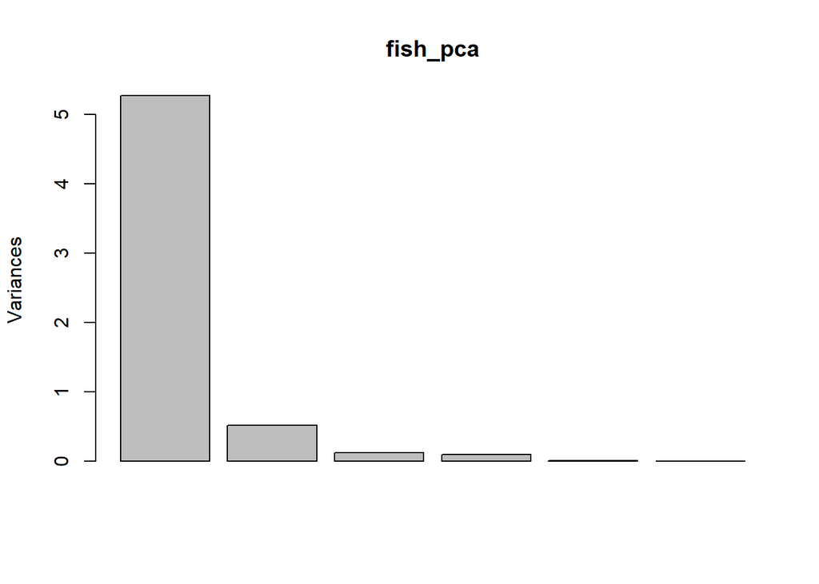

```r
plot(fish_pca)
```

```r
# A table containing eigenvalues and %'s accounted, follows. Eigenvalues are the sdev^2
(eigen_fish <- round(fish_pca$sdev^2,3))
```

```
## [1] 5.268 0.512 0.121 0.097 0.002 0.000
```

```r
round(fit.pc_fish$values, 3)
```

```
## [1] 5.268 0.512 0.121 0.097 0.002 0.000
```

```r
names(eigen_fish) <- paste("PC",1:6,sep="")
eigen_fish
```

```
##   PC1   PC2   PC3   PC4   PC5   PC6
## 5.268 0.512 0.121 0.097 0.002 0.000
```

```r
sumlambdas <- sum(eigen_fish)
sumlambdas
```

```
## [1] 6
```

```r
propvar <- round(eigen_fish/sumlambdas,2)
propvar
```

```
##  PC1  PC2  PC3  PC4  PC5  PC6
## 0.88 0.09 0.02 0.02 0.00 0.00
```

```r
cumvar_fish <- cumsum(propvar)
cumvar_fish
```

```
##  PC1  PC2  PC3  PC4  PC5  PC6
## 0.88 0.97 0.99 1.01 1.01 1.01
```

```r
matlambdas <- rbind(eigen_fish,propvar,cumvar_fish)
matlambdas
```

```
##               PC1   PC2   PC3   PC4   PC5  PC6
## eigen_fish  5.268 0.512 0.121 0.097 0.002 0.00
## propvar     0.880 0.090 0.020 0.020 0.000 0.00
## cumvar_fish 0.880 0.970 0.990 1.010 1.010 1.01
```

```r
rownames(matlambdas) <- c("Eigenvalues","Prop. variance","Cum. prop. variance")
rownames(matlambdas)
```

```
## [1] "Eigenvalues"         "Prop. variance"      "Cum. prop. variance"
```

```r
eigvec.fish <- fish_pca$rotation
print(fish_pca)
```

```
## Standard deviations (1, .., p=6):
## [1] 2.29530871 0.71538652 0.34733807 0.31189605 0.03974234 0.01666500
##
## Rotation (n x k) = (6 x 6):
##               PC1         PC2        PC3         PC4         PC5          PC6
## Weight  0.4174145 -0.03934572  0.2195906  0.88064340  0.02130717  0.003194724
## Length1 0.4215573 -0.33510472 -0.1659288 -0.15960339 -0.47183600 -0.659059494
## Length2 0.4234438 -0.30863947 -0.1721405 -0.16629765 -0.33015927  0.747759733
## Length3 0.4276972 -0.19677220 -0.3322752 -0.14772533  0.79986934 -0.079594435
## Height  0.3425075  0.84288953 -0.3890823 -0.02421089 -0.14226749 -0.003821636
## Width   0.4105041  0.20424583  0.7955020 -0.38591465  0.08877305 -0.011656740
```

```r
# Taking the first two PCs to generate linear combinations for all the variables with two factors
pcafactors.fish <- eigvec.fish[,1:2]
pcafactors.fish
```

```
##               PC1         PC2
## Weight  0.4174145 -0.03934572
## Length1 0.4215573 -0.33510472
## Length2 0.4234438 -0.30863947
## Length3 0.4276972 -0.19677220
## Height  0.3425075  0.84288953
## Width   0.4105041  0.20424583
```

```r
# Multiplying each column of the eigenvector’s matrix by the square-root of the corresponding eigenvalue in order to get the factor loadings
unrot.fact.fish <- sweep(pcafactors.fish,MARGIN=2,fish_pca$sdev[1:2],`*`)
unrot.fact.fish
```

```
##               PC1         PC2
## Weight  0.9580952 -0.02814739
## Length1 0.9676042 -0.23972940
## Length2 0.9719343 -0.22079652
## Length3 0.9816971 -0.14076818
## Height  0.7861604  0.60299181
## Width   0.9422335  0.14611471
```

```r
# Computing communalities
communalities.fish <- rowSums(unrot.fact.fish^2)
communalities.fish
```

```
##    Weight   Length1   Length2   Length3    Height     Width
## 0.9187387 0.9937281 0.9934073 0.9835449 0.9816473 0.9091535
```

```r
# Performing the varimax rotation. The default in the varimax function is norm=TRUE thus, Kaiser normalization is carried out
rot.fact.fish <- varimax(unrot.fact.fish)
#View(unrot.fact.fish)
rot.fact.fish
```

```
## $loadings
##
## Loadings:
##         PC1   PC2
## Weight  0.820 0.496
## Length1 0.943 0.324
## Length2 0.936 0.342
## Length3 0.901 0.415
## Height  0.333 0.933
## Width   0.712 0.634
##
##                  PC1   PC2
## SS loadings    3.867 1.913
## Proportion Var 0.645 0.319
## Cumulative Var 0.645 0.963
##
## $rotmat
##            [,1]      [,2]
## [1,]  0.8398878 0.5427600
## [2,] -0.5427600 0.8398878
```

Loadings: For PC1, Weight, Length1, Length2 and Length3 have high loadings which indicate that they contribute significantly to PC1.

SS Loadings: It indicates the amount of variance explained by each PC. For instance, PC1 explains 3.867 units of variance, while PC2 explains 1.913 units.

Proportion Variance: It represents the percentage of total variance explained by each PC. Here, PC1 explains 64.5% of the total variance, while PC2 explains 31.9%.

Cummulative Varicance: It indicates how much of the total variance is explained cumulatively by each PC. Here, after PC1 and PC2, 96.3% of the total variance is explained.

3. Show the columns that go into each factor.

```r
# The print method of varimax omits loadings less than abs(0.1). In order to display all the loadings, it is necessary to ask explicitly the contents of the object $loadings
fact.load.fish <- rot.fact.fish$loadings[1:6,1:2]
fact.load.fish
```

```
##               PC1       PC2
## Weight  0.8199698 0.4963751
## Length1 0.9427945 0.3238311
## Length2 0.9361553 0.3420828
## Length3 0.9009188 0.4145965
## Height  0.3330067 0.9331419
## Width   0.7120653 0.6341267
```

```r
scale.fish <- scale(fish_data[-1])
scale.fish
```

```
##             Weight       Length1     Length2      Length3      Height
##   [1,] -0.44408288 -0.3089507490 -0.28567896 -0.110115515  0.58977822
##   [2,] -0.30989139 -0.2290420634 -0.20181532 -0.006912838  0.81328400
##   [3,] -0.17010859 -0.2390306491 -0.18317895 -0.015513061  0.78948994
##   [4,] -0.10580850  0.0006954079  0.04977561  0.190892294  0.87148863
##   [5,]  0.08150045  0.0206725793  0.04977561  0.233893410  0.80490253
##   [6,]  0.13741357  0.0506383364  0.11500289  0.294094972  1.07459950
##   [7,]  0.27719637  0.0506383364  0.11500289  0.276894526  1.20895906
##   [8,] -0.03032579  0.1305470220  0.14295743  0.319895641  0.85751951
##   [9,]  0.13741357  0.1305470220  0.14295743  0.328495864  1.16830895
##  [10,]  0.27719637  0.2204442934  0.20818471  0.423098319  1.21992482
##  [11,]  0.20730497  0.2104557077  0.23613926  0.423098319  1.22835285
##  [12,]  0.27719637  0.2404214648  0.23613926  0.423098319  1.25363694
##  [13,]  0.27719637  0.2803758076  0.28273017  0.440298765  1.11110544
##  [14,] -0.17010859  0.3203301505  0.32932108  0.517700773  1.14688965
```

[output cut: 309 more lines]

```r
as.matrix(scale.fish)%*%fact.load.fish%*%solve(t(fact.load.fish)%*%fact.load.fish)
```

```
##                 PC1         PC2
##   [1,] -0.654230011  0.70742469
##   [2,] -0.648617874  0.95184347
##   [3,] -0.611417838  1.01075702
##   [4,] -0.389473139  0.89562117
##   [5,] -0.301634541  0.95804065
##   [6,] -0.373483216  1.17477631
##   [7,] -0.423290892  1.39821643
##   [8,] -0.240418189  0.85206693
##   [9,] -0.367391197  1.22315473
##  [10,] -0.277700943  1.25301118
##  [11,] -0.288406056  1.28284701
##  [12,] -0.275589406  1.24702462
##  [13,] -0.161338412  0.97917569
##  [14,] -0.205274198  1.10055786
```

[output cut: 144 more lines]

```r
# Show the columns (variables) that go into each factor
for (i in 1:ncol(fact.load.fish)) {
  cat("Variables for Factor PC", i, ":\n")
  print(rownames(fact.load.fish)[order(abs(fact.load.fish[, i]), decreasing = TRUE)])
  cat("\n")
}
```

```
## Variables for Factor PC 1 :
## [1] "Length1" "Length2" "Length3" "Weight"  "Width"   "Height"
##
## Variables for Factor PC 2 :
## [1] "Height"  "Width"   "Weight"  "Length3" "Length2" "Length1"
```

For PC1, “Length1” “Length2” “Length3” “Weight” are the primary influence.

For PC2, “Height” “Width” “Weight” “Length3” are the primary influence.

4. Perform some visualizations using the factors.

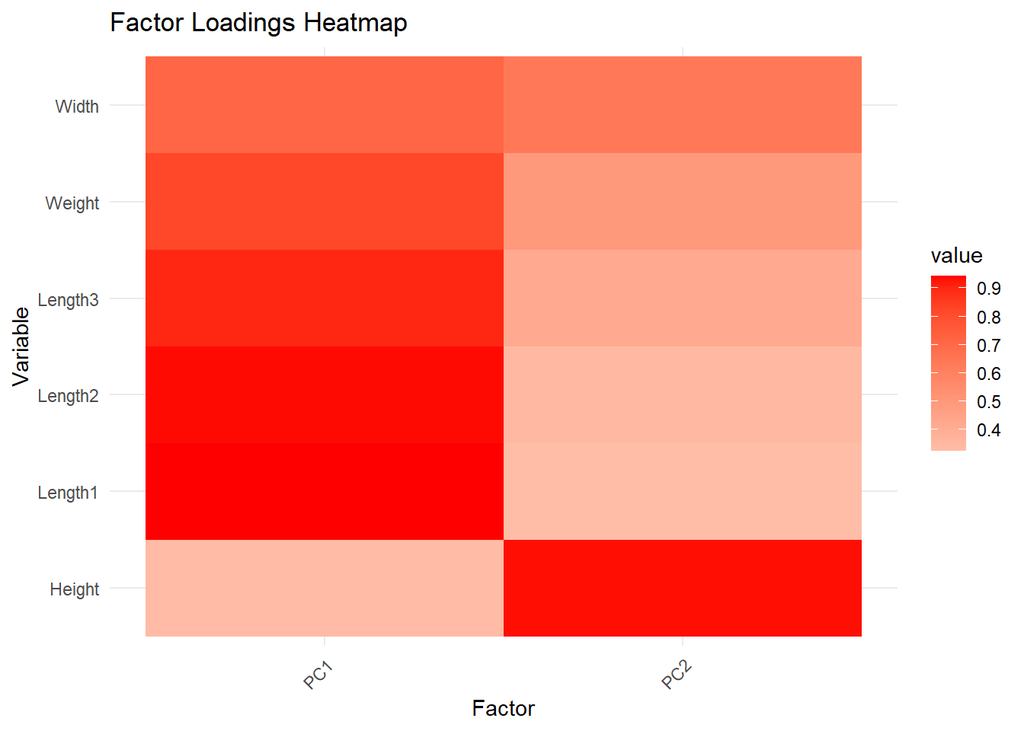

```r
# Convert factor loadings matrix to a data frame
fact_loadings_df <- as.data.frame(fact.load.fish)
# Add a column for variable names
fact_loadings_df$Variable <- rownames(fact_loadings_df)
# Reshape data for plotting
fact_loadings_df_long <- reshape2::melt(fact_loadings_df, id.vars = "Variable", variable.name = "Factor")

library(ggplot2)
#HeatMap
ggplot(fact_loadings_df_long, aes(x = Factor, y = Variable, fill = value)) +
     geom_tile() +
     scale_fill_gradient2(low = "blue", mid = "white", high = "red", midpoint = 0) +
     labs(x = "Factor", y = "Variable", title = "Factor Loadings Heatmap") +
     theme_minimal() +
     theme(axis.text.x = element_text(angle = 45, hjust = 1))
```

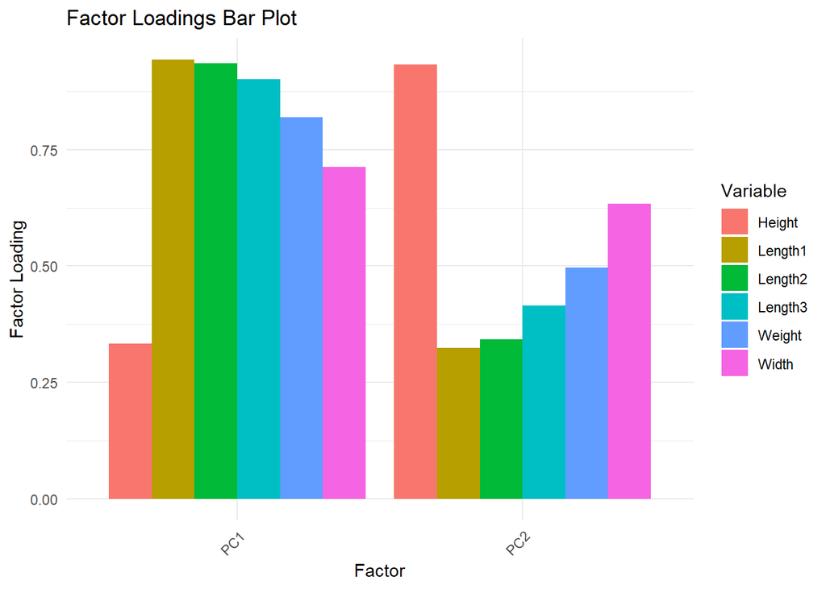

```r
#BarPlot
ggplot(fact_loadings_df_long, aes(x = Factor, y = value, fill = Variable)) +
     geom_bar(stat = "identity", position = "dodge") +
     labs(x = "Factor", y = "Factor Loading", fill = "Variable", title = "Factor Loadings Bar Plot") + theme_minimal() + theme(axis.text.x = element_text(angle = 45, hjust = 1),
           legend.position = "right")
```